# Characterizing Song Popularity using the MusicOSet Dataset

Kevin Liu

Jurti Telushi

2023-04-30

# Executive Summary

One of the key goals in the modern music industry is to understand the factors that influence a song’s popularity and underlie so-called “hit songs.” In this study, we use the Spotify-based MusicOSet dataset to analyze the relationship between a song’s acoustic and lyrical features and its subsequent popularity (or lack thereof). While the acoustic features are already provided in the dataset via the Spotify Web API, we perform text analysis ourselves to extract the lyrical features (i.e., frequencies of relevant words in the lyrics) for use in modeling.

We examine two response variables as proxies of song “popularity”: (1) `is_pop`, a binary variable based on the song’s peak position and time spent on the Billboard Hot 100 (where 1 indicates a popular song), and (2) `popularity`, a Spotify-based integer variable between 0 (not popular) to 100 (popular) based on the song’s number of plays, as well as their recency.

First, to understand which features are significant and what relationships are present, we perform LASSO regression to select ideal subsets of features, followed by linear and logistic regression on `popularity` and `is_pop`, respectively. We find that the two sets of significantly correlated coefficients share a few similarities - for example, `year` is significant in both models - but are largely different and even inconsistent at times. For example, songs from more recent years tend to have a higher `popularity` score (since recency is emphasized) but are less likely to be considered popular under `is_pop`. In addition, most words have negative associations with the response variables, although most are not significant.

We then explore various classification models and evaluate their performances in predicting `is_pop`. Besides the aforementioned logistic regression model, we also consider a feedforward neural network and a random forest model. We experience difficulties in constructing a well-trained neural network and thus removed it from consideration. In addition, the logistic regression and random forest models yield areas under the curve (AUCs) below 0.6, suggesting poor predictive performance. Ultimately, we compare these two models by evaluating their weighted misclassification errors (WMCEs), where false positives were penalized five times as much as false negatives. We find the WMCE of the logistic regression model (0.0948) to be lower than that of the random forest model (0.126), suggesting that the former may be more appropriate for this context. Despite our difficulties in constructing a strong predictive model, we still believe this project contains useful insights regarding the importance (or lack thereof) of certain acoustic and lyrical features with respect to song popularity.

# Introduction

## Background

In 2022, the world-wide music industry was worth a whopping $26.2 billion. By 2030, it is estimated that the industry would grow to $50.0 billion, representing one of the fastest growing industries of the decade, with an annual average growth of 9% per year. The upcoming decade presents a new golden era for the music industry after a two decade decline, starting in the early 90s. In fact, the music industry is responsible for the partial or full employment of up to 5 million artists, with the number to increase in the upcoming years, thus presenting a significant employment market. Yet, despite the large number of artists/singer and their output, the major revenues in the music industry are a result of small set of highly popular, and consequently highly profitable, artists and songs.

Figuring out a way to predict the popularity of a song, in advance of it coming to the popular audience, would represent a golden goose to the music industry as a whole. With advances in data science techniques and methods, we hope to be able to create a model that is capable of predicting a song’s success starting from the lyrics, as well as other data about the song.

## Goal

The ability to predict a song’s popularity would present a big advantage to the music industry as a whole. Thus, the goal of this project is twofold: (1) To identify and understand key trends that underlie song popularity, and (2) to construct a model for predicting song popularity. We hope to find, via analysis of song lyrics, whether there exist words/phrases which make a song more popular or otherwise. We expect that certain song features will also be significant.

## Description of Data

The data we use in this study comes entirely from the `MusicOSet` data set, which is a publicly available music database, containing information from over 20,000 songs, 11,000 artists, and 26,000 albums. The data set covers an extensive period of time, starting from the early 1960s to 2018. Much of the dataset was obtained from Spotify music data via the Spotify Web API. (More information can be found in the [MusicOSet paper](https://marianaossilva.github.io/DSW2019/assets/data/paper.pdf).)

The dataset contains a variety of features for each song, including acoustic features (e.g., danceability, energy), lyrics, and other miscellaneous features (e.g., explicit vs. clean, solo vs. collaboration). A list of the non-lyrical features is provided in the table below:

| Variable | Type | Description |
| --- | --- | --- |
| `song_id` | character | A string of letters to identify the song |
| `year` | numerical | Year of the song’s ranking |
| `duration_ms` | numerical | Duration of song (in milliseconds) |
| `key` | factor | Estimated overall of the key of the track, as an integer (or -1 if no key was detected) |
| `mode` | boolean | Whether the modality of the song is major (1) or minor (0) |
| `time_signature` | factor | Estimated overall time signature of the song |
| `acousticness` | numerical | Confidence measure from 0 (low confidence) to 1 (high confidence) of whether the song is acoustic |
| `danceability` | numerical | Measure from 0 (least danceable) to 1 (most danceable) of how suitable the song is for dancing |
| `energy` | numerical | Perceptual measure from 0 to 1 of the song’s intensity/activity |
| `instrumentalness` | numerical | Measure from 0 (unlikely) to 1 (likely) of how likely the song contains no vocals |
| `liveness` | numerical | Measure from 0 (unlikely) to 1 (likely) of how likely the recording was performed in front of an audience |
| `loudness` | numerical | Overall loudness of song (in decibels) |
| `speechiness` | numerical | Measure from 0 to 1 of how speech-like (i.e., presence of spoken words) the song is |
| `valence` | numerical | Measure from 0 (negative) to 1 (positive) of how musically positive a song is |
| `tempo` | numerical | Estimated tempo of a track (in beats per minute) |
| `explicit` | boolean | Whether the song contains explicit lyrics (1) or not (or unknown) (0) |
| `song_type` | factor | Whether the song was a collaboration or only involved one artist (solo) |

# Data Analysis

## Text Analysis

Though for each song we were presented the corresponding lyrics, to make the lyrics data easier to use as features in our models, we first extracted their corresponding word frequencies. To do so we first process the data by removing line breaks, as well as punctuation such as backslashes which were present in how the data was formatted. We then remove those songs whose lyrics are not present, which represented only a small fraction of the total songs. To process the resulting lyric data we then further remove special characters, such as punctuation and numbers, and convert alphabetic characters to lowercase. Furthermore, we remove common English stop words, such as with or I, and remove extraneous characters that are not the stem of the word.

From this processed data, we create a document-term matrix of word frequencies in each song, and we keep only those words that appear in at least 5% of songs. The reason for such a large cutoff was to make the data more manageable for our analysis. We ultimately obtain frequencies for about 500 words (including some explicit ones), which we use as text features in our models.

## Exploratory Data Analysis

### Non Lyrical Features

First, we explore the distributions of the non-lyrical features. The following graphs shows the histograms for numeric values in our data set:

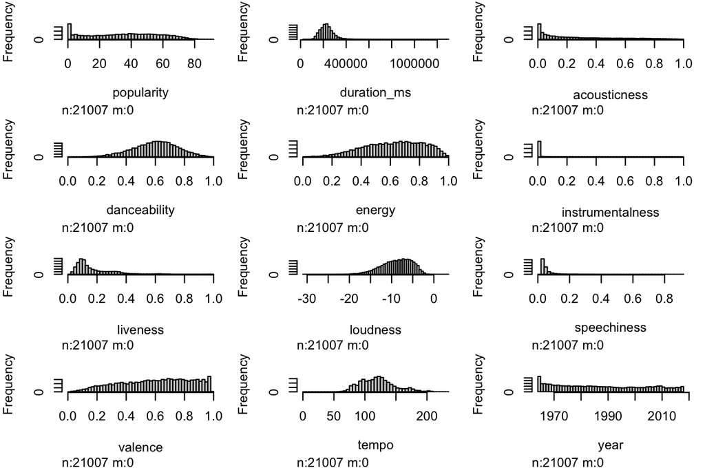

To increase the variability in the `instrumentalness` and `speechiness` variables and thus make them more useful for the purposes of our analyses, we decide to take a log of each variable, which yields the following distributions (with `instrumentalness` at top and `speechiness` at bottom):

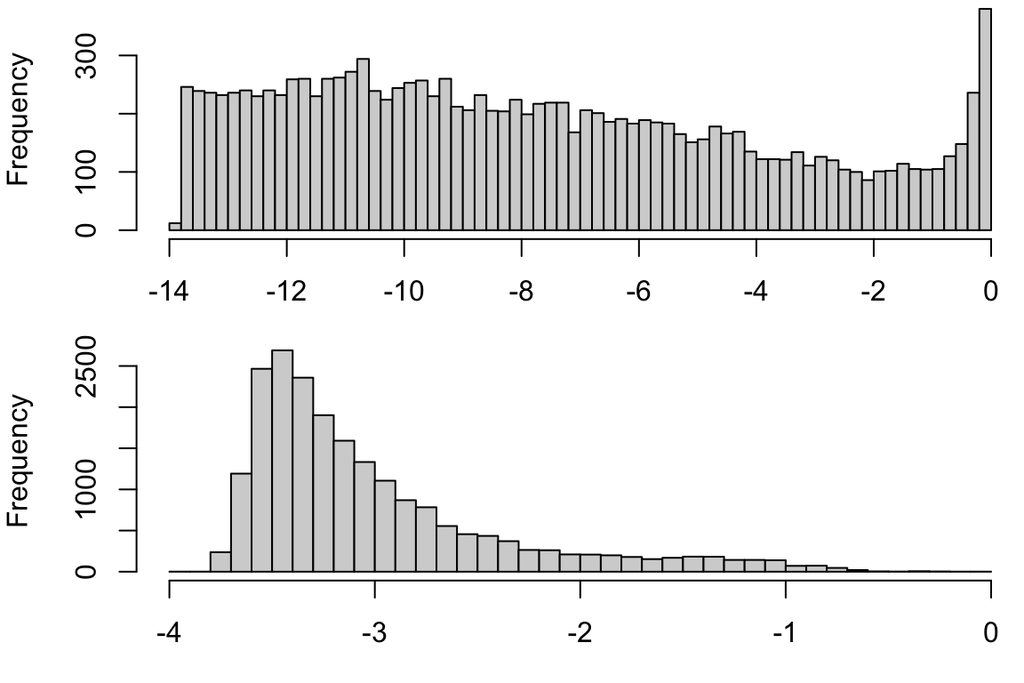

We now present bar plots of our categorical variables:

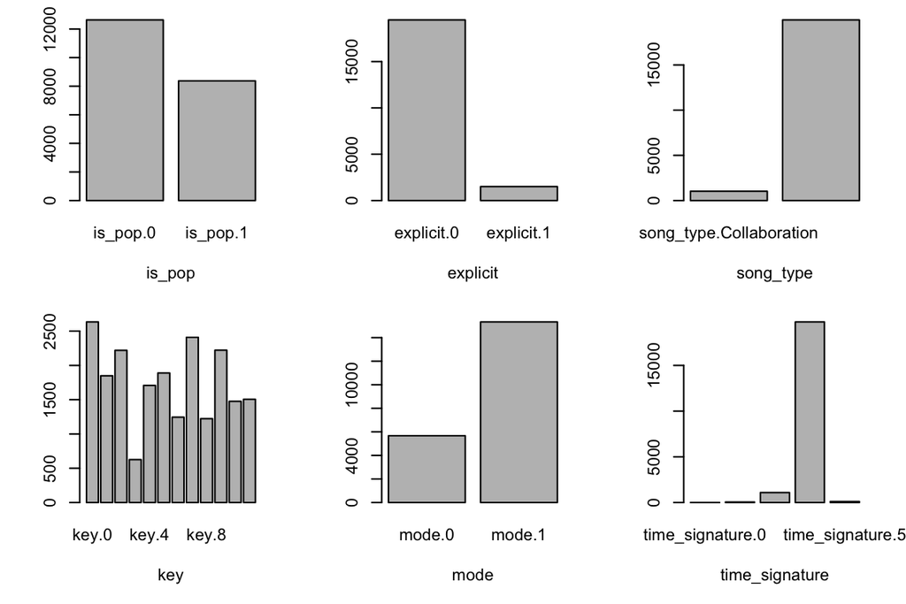

To explore the relationships between pairs of numerical variables, we examine the correlation heatmap:

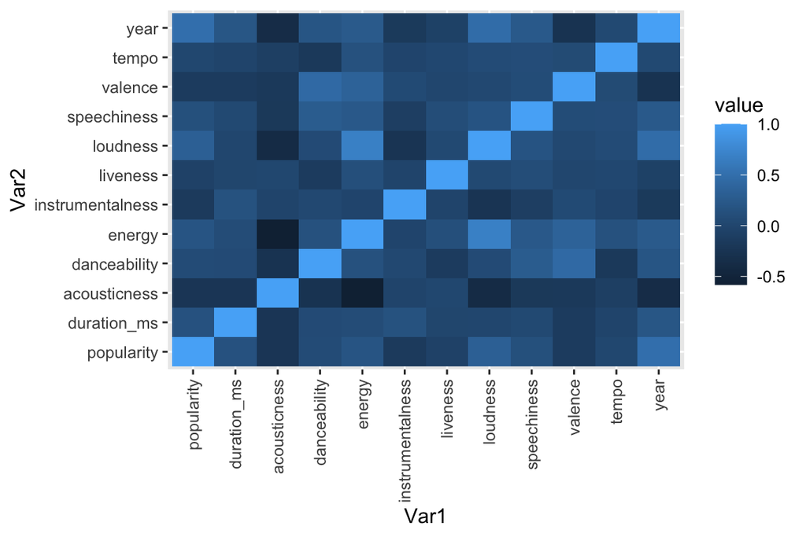

Finally, recall that we consider two measure of song popularity): `is_pop` (based on the song’s chart position) and `popularity` (based on the song’s number of plays and their recency). We hypothesize that these two variables are correlated but not identical, and we can explore this idea by considering the distribution of `popularity` based on `is_pop`:

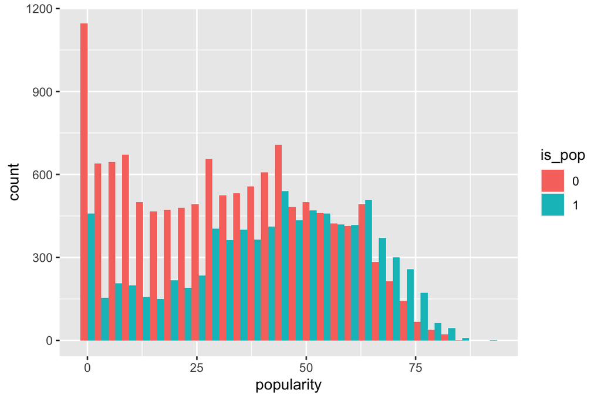

### Lyrical Features

Here we present the bar plots of the 30 least common words in our data set, as well as the 30 most common words, though given that we choose a threshold of $5\%$, means that all words presented are at least relatively common in all songs:

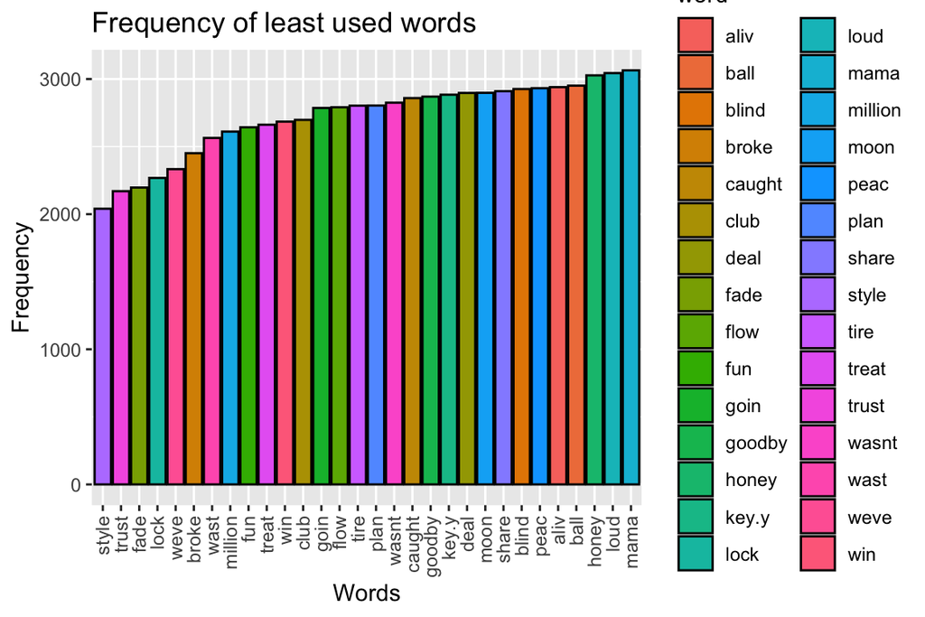

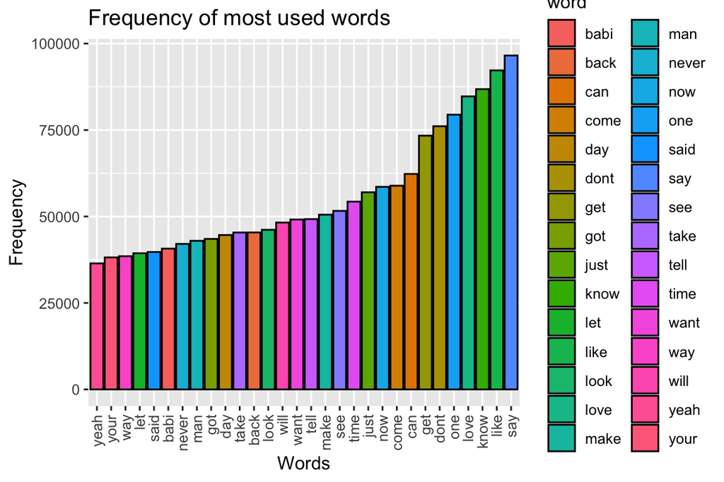

# Model Building

## Training/Testing/Validation Data

To remain consistent across all models we decide to split the data along Training/Testing/Validation subsets each containing $60\%/20\%/20\%$ of the the data respectively. Moreover, in order for our data to remain consistent we set seed to 10.

## Linear Regression

To start our analysis, we first attempted to model the continuous response variable `popularity` via a linear regression model on all variables, including lyrics. To do this, we first perform LASSO regression to find an ideal subset of features to use. We choose the optimal regularization parameter via cross-validation. In running LASSO regression, we choose $\alpha=0.99$ (to incorporate a small amount of ridge regression) and $nfolds = 10$.

The resulting Mean-Squared Error vs Tuning Parameter plot is given below:

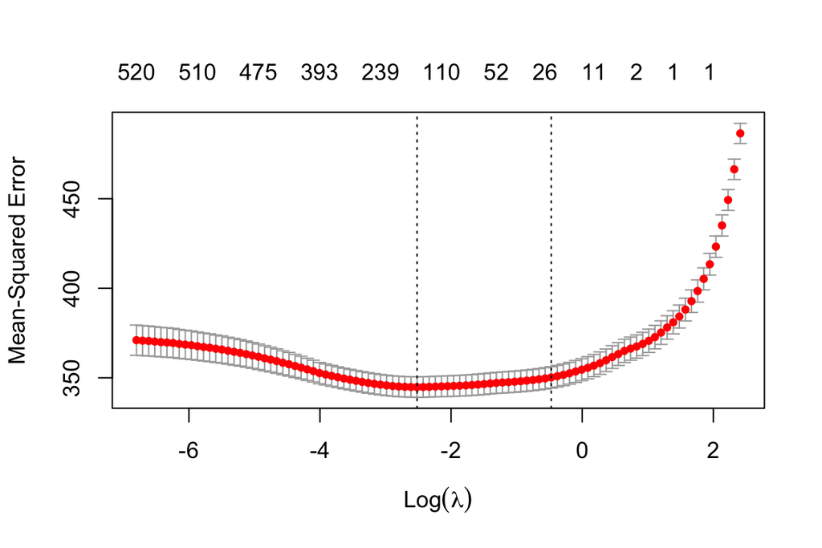

We then choose the linear model resulting from lambda.1se, which gives us a smaller model. The summary of the model is as follows:

```
##
## Call:
## glm(formula = y.num.train ~ ., data = data_sub)
##
## Deviance Residuals:
##     Min       1Q   Median       3Q      Max
## -57.319  -13.232    0.674   13.141   57.891
##
## Coefficients:
##                    Estimate Std. Error t value Pr(>|t|)
## (Intercept)      -9.870e+02  2.533e+01 -38.968  < 2e-16 ***
## year              5.116e-01  1.270e-02  40.273  < 2e-16 ***
## duration_ms       2.509e-05  2.787e-06   9.005  < 2e-16 ***
## mode             -1.449e+00  3.802e-01  -3.810  0.00014 ***
## acousticness     -1.069e+00  7.271e-01  -1.470  0.14167
## instrumentalness -3.812e-01  4.022e-02  -9.480  < 2e-16 ***
## liveness         -5.824e+00  1.044e+00  -5.578 2.49e-08 ***
## loudness          6.875e-01  5.668e-02  12.128  < 2e-16 ***
## act              -1.831e-01  1.013e-01  -1.808  0.07068 .
## ass              -4.258e-01  1.529e-01  -2.784  0.00537 **
## deep             -2.318e-01  1.775e-01  -1.306  0.19146
## full              1.429e-01  1.675e-01   0.853  0.39370
## game             -2.357e-01  1.712e-01  -1.377  0.16856
## got              -3.372e-02  3.827e-02  -0.881  0.37831
## key.y            -1.899e-01  1.741e-01  -1.091  0.27551
## lost             -5.784e-02  1.591e-01  -0.364  0.71622
## lot              -1.423e-01  1.354e-01  -1.050  0.29360
## mani             -2.506e-02  9.619e-02  -0.261  0.79448
## mine             -2.570e-01  1.170e-01  -2.196  0.02808 *
## pop              -2.905e-01  1.453e-01  -2.000  0.04556 *
## tight            -4.013e-01  2.361e-01  -1.699  0.08930 .
## trust            -3.754e-01  2.759e-01  -1.361  0.17367
## wit              -6.018e-01  1.672e-01  -3.599  0.00032 ***
## explicit1         6.424e+00  6.932e-01   9.268  < 2e-16 ***
## song_typeSolo     4.979e+00  7.619e-01   6.535 6.61e-11 ***
## ---
## Signif. codes:  0 '***' 0.001 '**' 0.01 '*' 0.05 '.' 0.1 ' ' 1
##
## (Dispersion parameter for gaussian family taken to be 345.8452)
##
##     Null deviance: 6136987  on 12603  degrees of freedom
## Residual deviance: 4350386  on 12579  degrees of freedom
## AIC: 109478
##
## Number of Fisher Scoring iterations: 2
```

We note the following from our results:

- `year` is significantly positively correlated with `popularity`, i.e., more recent songs tend to more “popular.” This makes sense since the Spotify popularity algorithm favors songs that were more recently played. (note that `popularity` is calculated from the number of times a song is played in Spotify)
- Other characteristics significantly associated with songs with higher `popularity` include having longer duration, being louder, having explicit lyrics, and involving a single artist.
- Characteristics significantly associated with songs with lower `popularity` include having a major modality, being more instrumental, and being recorded with an audience.
- For most words, word frequencies are negatively correlated with `popularity`, although the correlation is usually not significant. The most significantly correlated words include “wit” (negative) and “ass” (negative, which goes against our finding that songs with explicit songs tend to have a higher score).

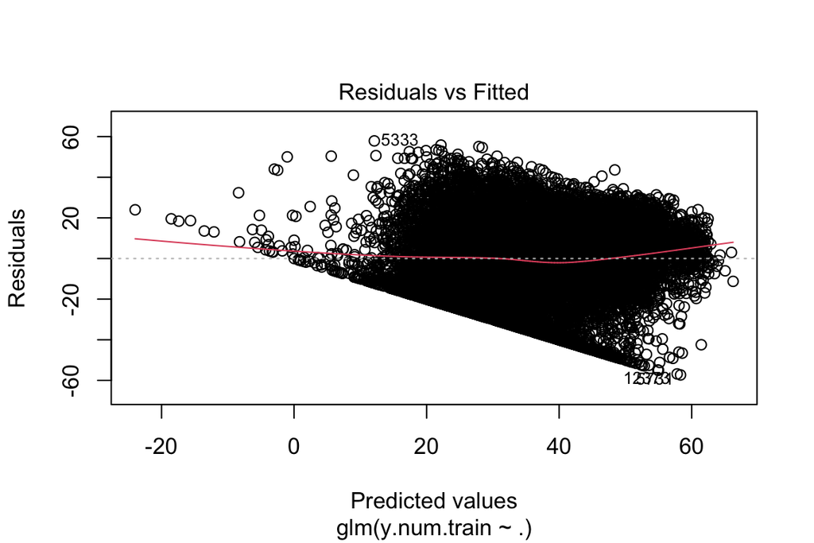

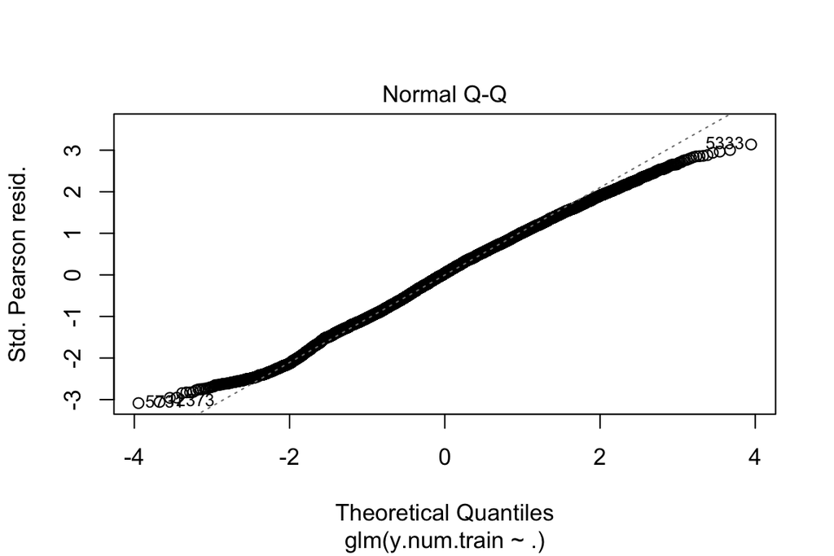

Looking at the QQ plot, we see that the tails do not deviate far from a straight line meaning that the normality assumptions is reasonably well met. On the other hand looking at the residual plot, we see that the residuals are not evenly distributed with respect to the fitted values, suggesting that further analysis may be necessary to reduce heteroskedasticity. On the other hand, the residuals seem to be distributed about the line $y=0$, meaning that the linearity assumption is well met.

## Logistic Regression

For the remainder of our modeling analysis, we will focus on modeling the binary response variable `is_pop` via various classification models. The first such model we consider is logistic regression. We follow a process similar to the one we used for linear regression.

We first perform LASSO logistic regression to find an ideal subset of features to use, choosing the optimal regularization parameter via cross-validation. The resulting Binomial Deviance vs Tunning Parameter is given below:

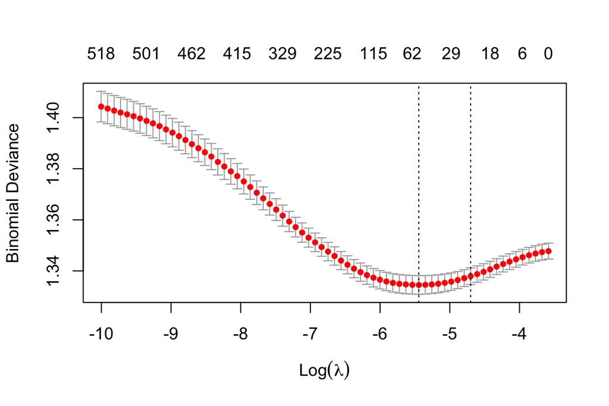

Again, we choose the linear model resulting from `lambda.1se`. We ultimately end up with 26 features , which are listed in the regression summary below. We then use these features to construct a logistic regression model, whose summary is as follows:

```
##
## Call:
## glm(formula = y.bin.train ~ ., family = binomial, data = data_sub)
##
## Deviance Residuals:
##     Min       1Q   Median       3Q      Max
## -1.8560  -1.0325  -0.9228   1.3015   2.8005
##
## Coefficients:
##                    Estimate Std. Error z value Pr(>|z|)
## (Intercept)       16.925031 119.493270   0.142 0.887364
## year              -0.003488   0.001252  -2.787 0.005327 **
## danceability       0.795328   0.134359   5.919 3.23e-09 ***
## energy            -0.209937   0.101337  -2.072 0.038297 *
## instrumentalness  -0.018487   0.004327  -4.273 1.93e-05 ***
## speechiness       -0.108538   0.035332  -3.072 0.002127 **
## babi               0.020730   0.003582   5.787 7.15e-09 ***
## deal              -0.042048   0.037084  -1.134 0.256858
## earth             -0.017391   0.025019  -0.695 0.486987
## flow              -0.014604   0.023020  -0.634 0.525828
## game              -0.037322   0.022418  -1.665 0.095946 .
## goin              -0.063322   0.025948  -2.440 0.014674 *
## gonna              0.023199   0.006233   3.722 0.000198 ***
## gun               -0.056433   0.024459  -2.307 0.021043 *
## lost              -0.014872   0.019468  -0.764 0.444938
## lot               -0.037636   0.019419  -1.938 0.052608 .
## nigga             -0.020212   0.008557  -2.362 0.018170 *
## peac              -0.039022   0.029562  -1.320 0.186842
## pretti            -0.025285   0.024936  -1.014 0.310594
## real              -0.006100   0.010417  -0.586 0.558185
## tight             -0.042953   0.031918  -1.346 0.178384
## win               -0.048739   0.036496  -1.335 0.181729
## explicit1         -0.085295   0.088204  -0.967 0.333536
## time_signature1  -12.349445 119.468911  -0.103 0.917670
## time_signature3  -11.467978 119.468095  -0.096 0.923527
## time_signature4  -11.211151 119.468079  -0.094 0.925234
## time_signature5  -11.190263 119.468355  -0.094 0.925374
## ---
## Signif. codes:  0 '***' 0.001 '**' 0.01 '*' 0.05 '.' 0.1 ' ' 1
##
## (Dispersion parameter for binomial family taken to be 1)
##
##     Null deviance: 16986  on 12603  degrees of freedom
## Residual deviance: 16719  on 12577  degrees of freedom
## AIC: 16773
##
## Number of Fisher Scoring iterations: 9
```

We note the following:

We present the ROC curve for the model:

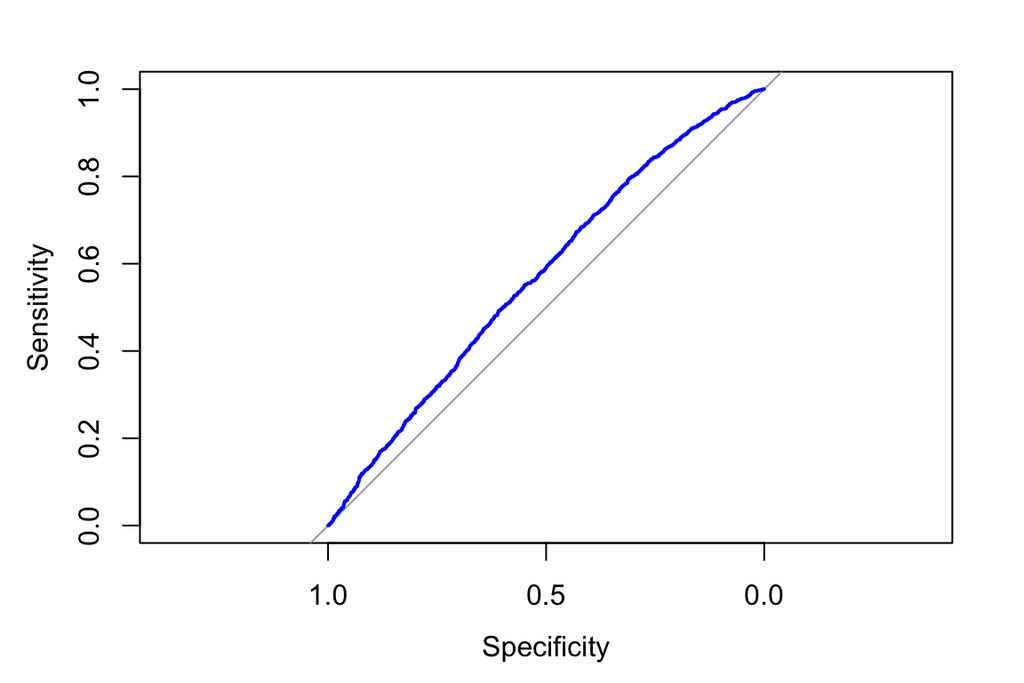

```
## Area under the curve: 0.5706
```

The ROC curve is very close to being a straight line and corresponds to an AUC of 0.5706, suggesting that our model is not well suited for predicting the popularity of a song.

## Neural Network

Given that we have about 500 word variables in our data set, we assumed that a neural network model would be a good choice for predicting a songs popularity. For our analyses we used the following network architecture:

```
## Model: "sequential"
## ________________________________________________________________________________
##  Layer (type)                       Output Shape                    Param #
## ================================================================================
##  dense_2 (Dense)                    (None, 16)                      8560
##  dense_1 (Dense)                    (None, 8)                       136
##  dense (Dense)                      (None, 2)                       18
## ================================================================================
## Total params: 8,714
## Trainable params: 8,714
## Non-trainable params: 0
## ________________________________________________________________________________
```

We train our model using 20 epochs and batch sizes of 256. The resulting loss and accuracy plots vs epoch are given below:

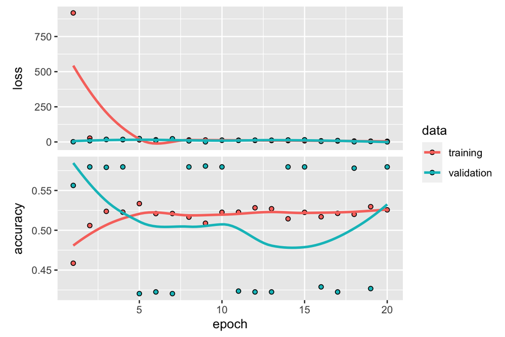

Clearly the results from the neural network seem to be severely wrong. In fact what seems to happen is that as our model is being trained, it “switches” back and forth from predicting that all songs are popular to predicting that none are popular. The validation accuracy changes from $60\%$ to $40\%$ which is roughly the split between unpopular and popular songs.

Since similar results seem to be the case for many different neural network architectures (not shown) we are left to conclude that a neural network is not able to predict a songs popularity with the given features in our data set. The fact that we only chose words with frequencies of greater than $5\%$ (and thus could have constrained the number of words far too greatly) could have played a role in the failure of the neural network model.

## Random Forest

The next and final model in our analysis is a Random Forest model. Since we are using some $500$ different variables in this model, we set $mtry=\sqrt{534}=\approx 23$. Moreover we set the number of trees for bagging to $500$ and get the resulting plot of OOB MSE vs number of trees:

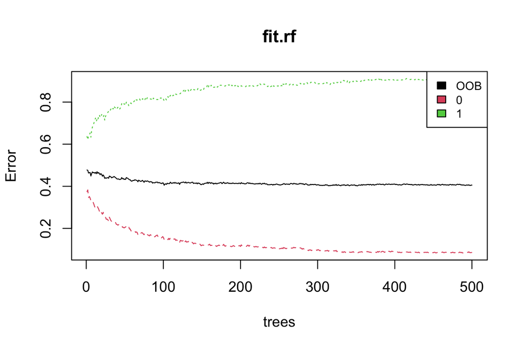

It seems that the OOB MSE error seems to settle down when the number of trees is 200.

We now plot the ROC curve of our model:

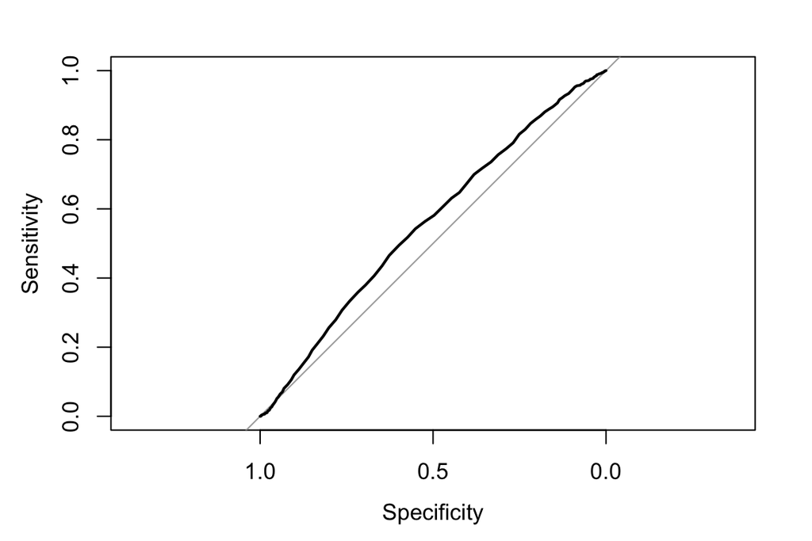

```
##
## Call:
## roc.default(response = test_data$y.bin.test, predictor = predict.rf[,     2], plot = TRUE)
##
## Data: predict.rf[, 2] in 2553 controls (test_data$y.bin.test 0) < 1648 cases (test_data$y.bin.test 1).
## Area under the curve: 0.5572
```

We see that the resulting ROC curve close to the $y=x$ line and obtain an AUC of 0.55. This suggests that the model’s predictive power is not ideal.

# Final Model

To find the best model for prediction, we first determine a suitable metric for comparison. We do not believe that accuracy of the given models would be a good predictor of the model itself, since not all misclassifications are equal. In particular, we believe that false positives (i.e., non-popular songs predicted to be popular) are less acceptable than false negatives (i.e., popular songs predicted to be non-popular). Thus, we define the following weighted misclassification error (WMCE)
$$WMCE=\frac{a_{1,0}
\sum_{i=1}^n 1 \{\hat{y}_i = 0 | y_i=1\} + a_{0,1} \sum_{i=1}^n 1
\{\hat{y}_i = 1 | y_i=0\}}{n}$$
where we choose $a_{1,0}/a_{0,1}=0.2$ (i.e., false positives are five times worse than false negatives). Calculating this $WMCE$ for our logistic regression and random forest classification models yields WMCEs of $0.0948$ and $0.126$, respectively. (We ignore the model resulting from (1) linear regression, as classification is not applicable, and (2) neural network, due to the aforementioned performance-based reasons.) Based on this metric, the logistic regression model appears the better model to go with for this context.

# Discussion

## Issues and Limitations

We would like to note a few limitations regarding our project. First, we experienced some computational difficulties with certain aspects of the project. For example, the hyperparameter tuning for the random forest model was computationally demanding, so we eventually performed this tuning with only a small subset (~10%) of the data to improve runtime. However, we tried to use all of the data in situations where it was possible to perform computations in a reasonable amount of time.

Second, with computational efficiency in mind, the MusicODataset itself included around 20,000 songs, which is only a small subset of songs available through the Spotify Web API. We could have incorporated more songs into our analysis, although we would not be able to use the `is_pop` response for those songs, since that was computed in the MusicOSet project. In addition, this could have presented more computational challenges.

Finally, our classification models were generally poor at prediction, which suggests that our current set of predictors (i.e., most of the ones included in the MusicODatset) is not effective. We did set the frequency threshold for word frequencies at 5%, and we could have expanded our set of lyrical features by lowering this threshold, although this could also increase computational runtime. In general, predicting `is_pop` using this dataset may be an inherently difficult task.

## Conclusion

We find that, from the MusicODataset, it is difficult to construct an effective model for prediction. While a logistic regression model seemed to perform best, given that it had an AUC below $0.6$, this model still does not seem to be sufficient for prediction.

Despite these shortcomings, we gained some useful descriptive insights our regression analysis. We found some features to be significantly correlated with either `is_pop` (chart-based popularity) or `popularity` (play-based popularity). In particular, we find that the set of significant features for `is_pop` is mostly different from that for `popularity`. In additions, features such as year seem to have differing effects based on the response variable, making it difficult to draw any concrete conclusions. Overall, even though our models have room for improvement in their predictive power, they still yield some meaningful descriptive results regarding the effects of certain features and words on song popularity.

# References

Silva, M. O., Rocha, L. M., & Moro, M. M. (2019). MusicOSet: An Enhanced Music Dataset for Music Data Mining. MusicOSet. Retrieved 2023, from https://marianaossilva.github.io/DSW2019/assets/data/paper.pdf